# Risk Factor Analysis

## Outcome Variable

**Outcome Variable:** ever_stunted

## Predictor Variables

**Intervention Variable:** exclfeed3

**Adjustment Set:**

- arm
- sex
- brthmon
- W_mage
- meducyrs
- feducyrs
- hhwealth_quart
- hfoodsec
- W_mhtcm
- W_mwtkg
- W_mbmi
- vagbrth
- W_gagebrth
- W_birthwt
- W_birthlen
- W_nrooms
- W_nchldlt5
- month
- W_parity
- impfloor
- impsan
- safeh20
- delta_W_mage
- delta_meducyrs
- delta_feducyrs
- delta_hhwealth_quart
- delta_hfoodsec
- delta_W_mhtcm
- delta_W_mwtkg
- delta_W_mbmi
- delta_vagbrth
- delta_W_gagebrth
- delta_W_birthwt
- delta_W_birthlen
- delta_W_nrooms
- delta_W_nchldlt5
- delta_month
- delta_W_parity
- delta_impfloor
- delta_impsan
- delta_safeh20

## Stratifying Variables

The analysis was stratified on these variable(s):

- agecat
- studyid
- country

## Data Summary

| agecat | studyid | country | exclfeed3 | ever_stunted | n_cell | n |
| --- | --- | --- | --- | --- | --- | --- |
| 0-24 months (no birth st.) | CMC-V-BCS-2002 | INDIA | 1 | 0 | 0 | 8 |
| 0-24 months (no birth st.) | CMC-V-BCS-2002 | INDIA | 1 | 1 | 8 | 8 |
| 0-24 months (no birth st.) | CMC-V-BCS-2002 | INDIA | 0 | 0 | 0 | 8 |
| 0-24 months (no birth st.) | CMC-V-BCS-2002 | INDIA | 0 | 1 | 0 | 8 |
| 0-24 months (no birth st.) | EE | PAKISTAN | 1 | 0 | 4 | 21 |
| 0-24 months (no birth st.) | EE | PAKISTAN | 1 | 1 | 17 | 21 |
| 0-24 months (no birth st.) | EE | PAKISTAN | 0 | 0 | 0 | 21 |
| 0-24 months (no birth st.) | EE | PAKISTAN | 0 | 1 | 0 | 21 |
| 0-24 months (no birth st.) | GMS-Nepal | NEPAL | 1 | 0 | 116 | 380 |
| 0-24 months (no birth st.) | GMS-Nepal | NEPAL | 1 | 1 | 201 | 380 |
| 0-24 months (no birth st.) | GMS-Nepal | NEPAL | 0 | 0 | 22 | 380 |
| 0-24 months (no birth st.) | GMS-Nepal | NEPAL | 0 | 1 | 41 | 380 |
| 0-24 months (no birth st.) | IRC | INDIA | 1 | 0 | 0 | 10 |
| 0-24 months (no birth st.) | IRC | INDIA | 1 | 1 | 0 | 10 |
| 0-24 months (no birth st.) | IRC | INDIA | 0 | 0 | 3 | 10 |
| 0-24 months (no birth st.) | IRC | INDIA | 0 | 1 | 7 | 10 |
| 0-24 months (no birth st.) | JiVitA-3 | BANGLADESH | 1 | 0 | 6792 | 10148 |
| 0-24 months (no birth st.) | JiVitA-3 | BANGLADESH | 1 | 1 | 2424 | 10148 |
| 0-24 months (no birth st.) | JiVitA-3 | BANGLADESH | 0 | 0 | 689 | 10148 |
| 0-24 months (no birth st.) | JiVitA-3 | BANGLADESH | 0 | 1 | 243 | 10148 |
| 0-24 months (no birth st.) | JiVitA-4 | BANGLADESH | 1 | 0 | 63 | 113 |
| 0-24 months (no birth st.) | JiVitA-4 | BANGLADESH | 1 | 1 | 40 | 113 |
| 0-24 months (no birth st.) | JiVitA-4 | BANGLADESH | 0 | 0 | 4 | 113 |
| 0-24 months (no birth st.) | JiVitA-4 | BANGLADESH | 0 | 1 | 6 | 113 |
| 0-24 months (no birth st.) | Keneba | GAMBIA | 1 | 0 | 759 | 1835 |
| 0-24 months (no birth st.) | Keneba | GAMBIA | 1 | 1 | 874 | 1835 |
| 0-24 months (no birth st.) | Keneba | GAMBIA | 0 | 0 | 91 | 1835 |
| 0-24 months (no birth st.) | Keneba | GAMBIA | 0 | 1 | 111 | 1835 |
| 0-24 months (no birth st.) | MAL-ED | BANGLADESH | 1 | 0 | 61 | 202 |
| 0-24 months (no birth st.) | MAL-ED | BANGLADESH | 1 | 1 | 71 | 202 |

[output cut: 98 more lines]

The following strata were considered:

- agecat: 0-24 months (no birth st.), studyid: CMC-V-BCS-2002, country: INDIA
- agecat: 0-24 months (no birth st.), studyid: EE, country: PAKISTAN
- agecat: 0-24 months (no birth st.), studyid: GMS-Nepal, country: NEPAL
- agecat: 0-24 months (no birth st.), studyid: IRC, country: INDIA
- agecat: 0-24 months (no birth st.), studyid: JiVitA-3, country: BANGLADESH
- agecat: 0-24 months (no birth st.), studyid: JiVitA-4, country: BANGLADESH
- agecat: 0-24 months (no birth st.), studyid: Keneba, country: GAMBIA
- agecat: 0-24 months (no birth st.), studyid: MAL-ED, country: BANGLADESH
- agecat: 0-24 months (no birth st.), studyid: MAL-ED, country: BRAZIL
- agecat: 0-24 months (no birth st.), studyid: MAL-ED, country: INDIA
- agecat: 0-24 months (no birth st.), studyid: MAL-ED, country: NEPAL
- agecat: 0-24 months (no birth st.), studyid: MAL-ED, country: PERU
- agecat: 0-24 months (no birth st.), studyid: MAL-ED, country: SOUTH AFRICA
- agecat: 0-24 months (no birth st.), studyid: MAL-ED, country: TANZANIA, UNITED REPUBLIC OF
- agecat: 0-24 months (no birth st.), studyid: PROVIDE, country: BANGLADESH
- agecat: 0-24 months (no birth st.), studyid: SAS-CompFeed, country: INDIA
- agecat: 0-6 months (no birth st.), studyid: CMC-V-BCS-2002, country: INDIA
- agecat: 0-6 months (no birth st.), studyid: EE, country: PAKISTAN
- agecat: 0-6 months (no birth st.), studyid: GMS-Nepal, country: NEPAL
- agecat: 0-6 months (no birth st.), studyid: IRC, country: INDIA
- agecat: 0-6 months (no birth st.), studyid: JiVitA-3, country: BANGLADESH
- agecat: 0-6 months (no birth st.), studyid: JiVitA-4, country: BANGLADESH
- agecat: 0-6 months (no birth st.), studyid: Keneba, country: GAMBIA
- agecat: 0-6 months (no birth st.), studyid: MAL-ED, country: BANGLADESH
- agecat: 0-6 months (no birth st.), studyid: MAL-ED, country: BRAZIL
- agecat: 0-6 months (no birth st.), studyid: MAL-ED, country: INDIA
- agecat: 0-6 months (no birth st.), studyid: MAL-ED, country: NEPAL
- agecat: 0-6 months (no birth st.), studyid: MAL-ED, country: PERU
- agecat: 0-6 months (no birth st.), studyid: MAL-ED, country: SOUTH AFRICA
- agecat: 0-6 months (no birth st.), studyid: MAL-ED, country: TANZANIA, UNITED REPUBLIC OF
- agecat: 0-6 months (no birth st.), studyid: PROVIDE, country: BANGLADESH
- agecat: 0-6 months (no birth st.), studyid: SAS-CompFeed, country: INDIA

### Dropped Strata

Some strata were dropped due to rare outcomes:

- agecat: 0-24 months (no birth st.), studyid: CMC-V-BCS-2002, country: INDIA
- agecat: 0-24 months (no birth st.), studyid: EE, country: PAKISTAN
- agecat: 0-24 months (no birth st.), studyid: IRC, country: INDIA
- agecat: 0-24 months (no birth st.), studyid: JiVitA-4, country: BANGLADESH
- agecat: 0-6 months (no birth st.), studyid: CMC-V-BCS-2002, country: INDIA
- agecat: 0-6 months (no birth st.), studyid: EE, country: PAKISTAN
- agecat: 0-6 months (no birth st.), studyid: IRC, country: INDIA
- agecat: 0-6 months (no birth st.), studyid: JiVitA-4, country: BANGLADESH
- agecat: 0-6 months (no birth st.), studyid: MAL-ED, country: NEPAL

## Methods Detail

We're interested in the causal parameters $E[Y_a]$ for all values of $a \in \mathcal{A}$. These parameters represent the mean outcome if, possibly contrary to fact, we intervened to set all units to have $A=a$. Under the randomization and positivity assumptions, these are identified by the statistical parameters $\psi_a=E_W[E_{Y|A,W}(Y|A=a,W)]$. In addition, we're interested in the mean of $Y$, $E[Y]$ under no intervention (the observed mean). We will estimate these parameters by using SuperLearner to fit the relevant likelihood factors -- $E_{Y|A,W}(Y|A=a,W)$ and $p(A=a|W)$, and then updating our likelihood fit using a joint TMLE.

For unadjusted analyses ($W=\{\}$), initial likelihoods were estimated using Lrnr_glm to estimate the simple $E(Y|A)$ and Lrnr_mean to estimate $p(A)$. For adjusted analyses, a small library containing Lrnr_glmnet, Lrnr_xgboost, and Lrnr_mean was used.

Having estimated these parameters, we will then use the delta method to estimate relative risks and attributable risks relative to a prespecified baseline level of $A$.

# Results Detail

## Results Plots

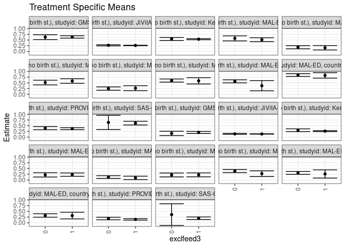

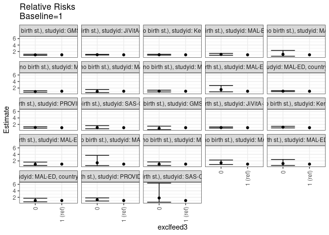

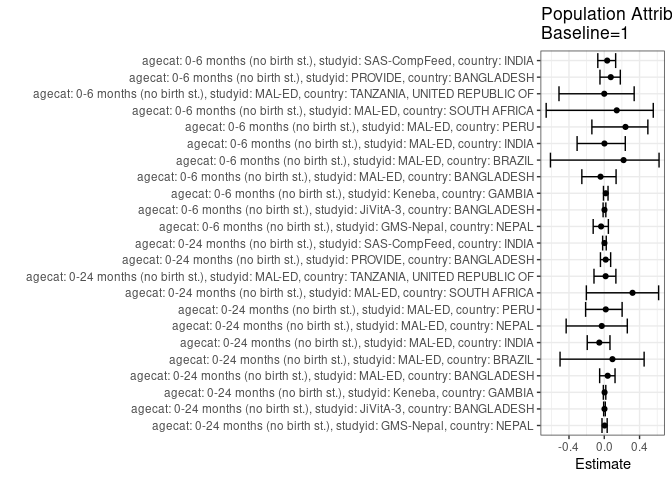

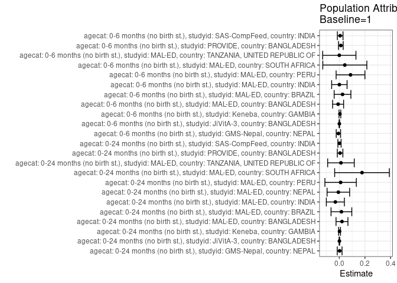

## Results Table

### Parameter: TSM

| agecat | studyid | country | intervention_level | baseline_level | estimate | ci_lower | ci_upper |
| --- | --- | --- | --- | --- | --- | --- | --- |
| 0-24 months (no birth st.) | GMS-Nepal | NEPAL | 1 | NA | 0.6343083 | 0.5815798 | 0.6870369 |
| 0-24 months (no birth st.) | GMS-Nepal | NEPAL | 0 | NA | 0.6249817 | 0.5192318 | 0.7307316 |
| 0-24 months (no birth st.) | JiVitA-3 | BANGLADESH | 1 | NA | 0.2622135 | 0.2514542 | 0.2729728 |
| 0-24 months (no birth st.) | JiVitA-3 | BANGLADESH | 0 | NA | 0.2684611 | 0.2427085 | 0.2942137 |
| 0-24 months (no birth st.) | Keneba | GAMBIA | 1 | NA | 0.5349436 | 0.5108978 | 0.5589894 |
| 0-24 months (no birth st.) | Keneba | GAMBIA | 0 | NA | 0.5459808 | 0.4791168 | 0.6128448 |
| 0-24 months (no birth st.) | MAL-ED | BANGLADESH | 1 | NA | 0.5139401 | 0.4303881 | 0.5974921 |
| 0-24 months (no birth st.) | MAL-ED | BANGLADESH | 0 | NA | 0.5718593 | 0.4602109 | 0.6835076 |
| 0-24 months (no birth st.) | MAL-ED | BRAZIL | 1 | NA | 0.1607143 | 0.0642469 | 0.2571817 |
| 0-24 months (no birth st.) | MAL-ED | BRAZIL | 0 | NA | 0.1848739 | 0.1149269 | 0.2548210 |
| 0-24 months (no birth st.) | MAL-ED | INDIA | 1 | NA | 0.5798789 | 0.4795307 | 0.6802272 |
| 0-24 months (no birth st.) | MAL-ED | INDIA | 0 | NA | 0.5142376 | 0.4119856 | 0.6164895 |
| 0-24 months (no birth st.) | MAL-ED | NEPAL | 1 | NA | 0.2661279 | 0.1579566 | 0.3742992 |
| 0-24 months (no birth st.) | MAL-ED | NEPAL | 0 | NA | 0.2493318 | 0.1756470 | 0.3230165 |
| 0-24 months (no birth st.) | MAL-ED | PERU | 1 | NA | 0.5867483 | 0.4491101 | 0.7243865 |
| 0-24 months (no birth st.) | MAL-ED | PERU | 0 | NA | 0.6010462 | 0.5330782 | 0.6690141 |
| 0-24 months (no birth st.) | MAL-ED | SOUTH AFRICA | 1 | NA | 0.3756745 | 0.1523448 | 0.5990041 |
| 0-24 months (no birth st.) | MAL-ED | SOUTH AFRICA | 0 | NA | 0.5657008 | 0.4990809 | 0.6323207 |
| 0-24 months (no birth st.) | MAL-ED | TANZANIA, UNITED REPUBLIC OF | 1 | NA | 0.8250000 | 0.7069296 | 0.9430704 |
| 0-24 months (no birth st.) | MAL-ED | TANZANIA, UNITED REPUBLIC OF | 0 | NA | 0.8413793 | 0.7817559 | 0.9010027 |
| 0-24 months (no birth st.) | PROVIDE | BANGLADESH | 1 | NA | 0.3699159 | 0.3265514 | 0.4132804 |
| 0-24 months (no birth st.) | PROVIDE | BANGLADESH | 0 | NA | 0.3925465 | 0.3241931 | 0.4608999 |
| 0-24 months (no birth st.) | SAS-CompFeed | INDIA | 1 | NA | 0.6121795 | 0.5306906 | 0.6936683 |
| 0-24 months (no birth st.) | SAS-CompFeed | INDIA | 0 | NA | 0.6428571 | 0.3329177 | 0.9527966 |
| 0-6 months (no birth st.) | GMS-Nepal | NEPAL | 1 | NA | 0.2044876 | 0.1600416 | 0.2489337 |
| 0-6 months (no birth st.) | GMS-Nepal | NEPAL | 0 | NA | 0.1614874 | 0.0670054 | 0.2559694 |
| 0-6 months (no birth st.) | JiVitA-3 | BANGLADESH | 1 | NA | 0.1369884 | 0.1290375 | 0.1449393 |
| 0-6 months (no birth st.) | JiVitA-3 | BANGLADESH | 0 | NA | 0.1418184 | 0.1197681 | 0.1638686 |
| 0-6 months (no birth st.) | Keneba | GAMBIA | 1 | NA | 0.2619220 | 0.2406185 | 0.2832255 |
| 0-6 months (no birth st.) | Keneba | GAMBIA | 0 | NA | 0.3002971 | 0.2405080 | 0.3600862 |
| 0-6 months (no birth st.) | MAL-ED | BANGLADESH | 1 | NA | 0.2321972 | 0.1599446 | 0.3044497 |
| 0-6 months (no birth st.) | MAL-ED | BANGLADESH | 0 | NA | 0.2218952 | 0.1274252 | 0.3163651 |
| 0-6 months (no birth st.) | MAL-ED | BRAZIL | 1 | NA | 0.0892857 | 0.0143859 | 0.1641855 |
| 0-6 months (no birth st.) | MAL-ED | BRAZIL | 0 | NA | 0.1260504 | 0.0662459 | 0.1858550 |
| 0-6 months (no birth st.) | MAL-ED | INDIA | 1 | NA | 0.2224254 | 0.1366826 | 0.3081683 |
| 0-6 months (no birth st.) | MAL-ED | INDIA | 0 | NA | 0.2177822 | 0.1338893 | 0.3016751 |
| 0-6 months (no birth st.) | MAL-ED | PERU | 1 | NA | 0.2762200 | 0.1529201 | 0.3995200 |
| 0-6 months (no birth st.) | MAL-ED | PERU | 0 | NA | 0.3872913 | 0.3196730 | 0.4549096 |
| 0-6 months (no birth st.) | MAL-ED | SOUTH AFRICA | 1 | NA | 0.2608696 | 0.0810344 | 0.4407047 |
| 0-6 months (no birth st.) | MAL-ED | SOUTH AFRICA | 0 | NA | 0.3084112 | 0.2464031 | 0.3704193 |
| 0-6 months (no birth st.) | MAL-ED | TANZANIA, UNITED REPUBLIC OF | 1 | NA | 0.3135728 | 0.1678171 | 0.4593286 |
| 0-6 months (no birth st.) | MAL-ED | TANZANIA, UNITED REPUBLIC OF | 0 | NA | 0.3190902 | 0.2428169 | 0.3953634 |
| 0-6 months (no birth st.) | PROVIDE | BANGLADESH | 1 | NA | 0.1478059 | 0.1151128 | 0.1804990 |
| 0-6 months (no birth st.) | PROVIDE | BANGLADESH | 0 | NA | 0.1848033 | 0.1296126 | 0.2399940 |
| 0-6 months (no birth st.) | SAS-CompFeed | INDIA | 1 | NA | 0.1987179 | 0.1419130 | 0.2555229 |
| 0-6 months (no birth st.) | SAS-CompFeed | INDIA | 0 | NA | 0.3571429 | -0.1170496 | 0.8313354 |

### Parameter: E(Y)

| agecat | studyid | country | intervention_level | baseline_level | estimate | ci_lower | ci_upper |
| --- | --- | --- | --- | --- | --- | --- | --- |
| 0-24 months (no birth st.) | GMS-Nepal | NEPAL | NA | NA | 0.6368421 | 0.5884257 | 0.6852585 |
| 0-24 months (no birth st.) | JiVitA-3 | BANGLADESH | NA | NA | 0.2628104 | 0.2524838 | 0.2731371 |
| 0-24 months (no birth st.) | Keneba | GAMBIA | NA | NA | 0.5367847 | 0.5139635 | 0.5596060 |
| 0-24 months (no birth st.) | MAL-ED | BANGLADESH | NA | NA | 0.5346535 | 0.4656971 | 0.6036099 |
| 0-24 months (no birth st.) | MAL-ED | BRAZIL | NA | NA | 0.1771429 | 0.1204149 | 0.2338709 |
| 0-24 months (no birth st.) | MAL-ED | INDIA | NA | NA | 0.5489130 | 0.4768182 | 0.6210079 |
| 0-24 months (no birth st.) | MAL-ED | NEPAL | NA | NA | 0.2587065 | 0.1980144 | 0.3193985 |
| 0-24 months (no birth st.) | MAL-ED | PERU | NA | NA | 0.5968379 | 0.5362738 | 0.6574021 |
| 0-24 months (no birth st.) | MAL-ED | SOUTH AFRICA | NA | NA | 0.5527426 | 0.4893071 | 0.6161781 |
| 0-24 months (no birth st.) | MAL-ED | TANZANIA, UNITED REPUBLIC OF | NA | NA | 0.8378378 | 0.7845787 | 0.8910970 |
| 0-24 months (no birth st.) | PROVIDE | BANGLADESH | NA | NA | 0.3759874 | 0.3382238 | 0.4137509 |
| 0-24 months (no birth st.) | SAS-CompFeed | INDIA | NA | NA | 0.6134969 | 0.5286303 | 0.6983636 |
| 0-6 months (no birth st.) | GMS-Nepal | NEPAL | NA | NA | 0.1973684 | 0.1572979 | 0.2374390 |
| 0-6 months (no birth st.) | JiVitA-3 | BANGLADESH | NA | NA | 0.1373090 | 0.1297510 | 0.1448670 |
| 0-6 months (no birth st.) | Keneba | GAMBIA | NA | NA | 0.2664850 | 0.2462507 | 0.2867194 |
| 0-6 months (no birth st.) | MAL-ED | BANGLADESH | NA | NA | 0.2227723 | 0.1652475 | 0.2802970 |
| 0-6 months (no birth st.) | MAL-ED | BRAZIL | NA | NA | 0.1142857 | 0.0670124 | 0.1615591 |
| 0-6 months (no birth st.) | MAL-ED | INDIA | NA | NA | 0.2228261 | 0.1625334 | 0.2831188 |
| 0-6 months (no birth st.) | MAL-ED | PERU | NA | NA | 0.3636364 | 0.3042435 | 0.4230292 |
| 0-6 months (no birth st.) | MAL-ED | SOUTH AFRICA | NA | NA | 0.3037975 | 0.2451226 | 0.3624723 |
| 0-6 months (no birth st.) | MAL-ED | TANZANIA, UNITED REPUBLIC OF | NA | NA | 0.3135135 | 0.2464813 | 0.3805457 |
| 0-6 months (no birth st.) | PROVIDE | BANGLADESH | NA | NA | 0.1595577 | 0.1310079 | 0.1881074 |
| 0-6 months (no birth st.) | SAS-CompFeed | INDIA | NA | NA | 0.2055215 | 0.1385538 | 0.2724891 |

### Parameter: RR

| agecat | studyid | country | intervention_level | baseline_level | estimate | ci_lower | ci_upper |
| --- | --- | --- | --- | --- | --- | --- | --- |
| 0-24 months (no birth st.) | GMS-Nepal | NEPAL | 1 | 1 | 1.0000000 | 1.0000000 | 1.000000 |
| 0-24 months (no birth st.) | GMS-Nepal | NEPAL | 0 | 1 | 0.9852964 | 0.8208098 | 1.182745 |
| 0-24 months (no birth st.) | JiVitA-3 | BANGLADESH | 1 | 1 | 1.0000000 | 1.0000000 | 1.000000 |
| 0-24 months (no birth st.) | JiVitA-3 | BANGLADESH | 0 | 1 | 1.0238263 | 0.9267687 | 1.131048 |
| 0-24 months (no birth st.) | Keneba | GAMBIA | 1 | 1 | 1.0000000 | 1.0000000 | 1.000000 |
| 0-24 months (no birth st.) | Keneba | GAMBIA | 0 | 1 | 1.0206325 | 0.8972203 | 1.161020 |
| 0-24 months (no birth st.) | MAL-ED | BANGLADESH | 1 | 1 | 1.0000000 | 1.0000000 | 1.000000 |
| 0-24 months (no birth st.) | MAL-ED | BANGLADESH | 0 | 1 | 1.1126962 | 0.8725032 | 1.419013 |
| 0-24 months (no birth st.) | MAL-ED | BRAZIL | 1 | 1 | 1.0000000 | 1.0000000 | 1.000000 |
| 0-24 months (no birth st.) | MAL-ED | BRAZIL | 0 | 1 | 1.1503268 | 0.5658150 | 2.338665 |
| 0-24 months (no birth st.) | MAL-ED | INDIA | 1 | 1 | 1.0000000 | 1.0000000 | 1.000000 |
| 0-24 months (no birth st.) | MAL-ED | INDIA | 0 | 1 | 0.8868016 | 0.6839829 | 1.149761 |
| 0-24 months (no birth st.) | MAL-ED | NEPAL | 1 | 1 | 1.0000000 | 1.0000000 | 1.000000 |
| 0-24 months (no birth st.) | MAL-ED | NEPAL | 0 | 1 | 0.9368869 | 0.5663635 | 1.549812 |
| 0-24 months (no birth st.) | MAL-ED | PERU | 1 | 1 | 1.0000000 | 1.0000000 | 1.000000 |
| 0-24 months (no birth st.) | MAL-ED | PERU | 0 | 1 | 1.0243680 | 0.7898358 | 1.328542 |
| 0-24 months (no birth st.) | MAL-ED | SOUTH AFRICA | 1 | 1 | 1.0000000 | 1.0000000 | 1.000000 |
| 0-24 months (no birth st.) | MAL-ED | SOUTH AFRICA | 0 | 1 | 1.5058271 | 0.8203666 | 2.764027 |
| 0-24 months (no birth st.) | MAL-ED | TANZANIA, UNITED REPUBLIC OF | 1 | 1 | 1.0000000 | 1.0000000 | 1.000000 |
| 0-24 months (no birth st.) | MAL-ED | TANZANIA, UNITED REPUBLIC OF | 0 | 1 | 1.0198537 | 0.8693236 | 1.196449 |
| 0-24 months (no birth st.) | PROVIDE | BANGLADESH | 1 | 1 | 1.0000000 | 1.0000000 | 1.000000 |
| 0-24 months (no birth st.) | PROVIDE | BANGLADESH | 0 | 1 | 1.0611777 | 0.8670207 | 1.298814 |
| 0-24 months (no birth st.) | SAS-CompFeed | INDIA | 1 | 1 | 1.0000000 | 1.0000000 | 1.000000 |
| 0-24 months (no birth st.) | SAS-CompFeed | INDIA | 0 | 1 | 1.0501122 | 0.6736522 | 1.636951 |
| 0-6 months (no birth st.) | GMS-Nepal | NEPAL | 1 | 1 | 1.0000000 | 1.0000000 | 1.000000 |
| 0-6 months (no birth st.) | GMS-Nepal | NEPAL | 0 | 1 | 0.7897172 | 0.4227208 | 1.475331 |
| 0-6 months (no birth st.) | JiVitA-3 | BANGLADESH | 1 | 1 | 1.0000000 | 1.0000000 | 1.000000 |
| 0-6 months (no birth st.) | JiVitA-3 | BANGLADESH | 0 | 1 | 1.0352579 | 0.8784722 | 1.220026 |
| 0-6 months (no birth st.) | Keneba | GAMBIA | 1 | 1 | 1.0000000 | 1.0000000 | 1.000000 |
| 0-6 months (no birth st.) | Keneba | GAMBIA | 0 | 1 | 1.1465133 | 0.9268640 | 1.418215 |
| 0-6 months (no birth st.) | MAL-ED | BANGLADESH | 1 | 1 | 1.0000000 | 1.0000000 | 1.000000 |
| 0-6 months (no birth st.) | MAL-ED | BANGLADESH | 0 | 1 | 0.9556325 | 0.5632928 | 1.621241 |
| 0-6 months (no birth st.) | MAL-ED | BRAZIL | 1 | 1 | 1.0000000 | 1.0000000 | 1.000000 |
| 0-6 months (no birth st.) | MAL-ED | BRAZIL | 0 | 1 | 1.4117647 | 0.5385303 | 3.700961 |
| 0-6 months (no birth st.) | MAL-ED | INDIA | 1 | 1 | 1.0000000 | 1.0000000 | 1.000000 |
| 0-6 months (no birth st.) | MAL-ED | INDIA | 0 | 1 | 0.9791246 | 0.5686577 | 1.685874 |
| 0-6 months (no birth st.) | MAL-ED | PERU | 1 | 1 | 1.0000000 | 1.0000000 | 1.000000 |
| 0-6 months (no birth st.) | MAL-ED | PERU | 0 | 1 | 1.4021117 | 0.8681961 | 2.264370 |
| 0-6 months (no birth st.) | MAL-ED | SOUTH AFRICA | 1 | 1 | 1.0000000 | 1.0000000 | 1.000000 |
| 0-6 months (no birth st.) | MAL-ED | SOUTH AFRICA | 0 | 1 | 1.1822430 | 0.5765601 | 2.424203 |
| 0-6 months (no birth st.) | MAL-ED | TANZANIA, UNITED REPUBLIC OF | 1 | 1 | 1.0000000 | 1.0000000 | 1.000000 |
| 0-6 months (no birth st.) | MAL-ED | TANZANIA, UNITED REPUBLIC OF | 0 | 1 | 1.0175951 | 0.6023367 | 1.719138 |
| 0-6 months (no birth st.) | PROVIDE | BANGLADESH | 1 | 1 | 1.0000000 | 1.0000000 | 1.000000 |
| 0-6 months (no birth st.) | PROVIDE | BANGLADESH | 0 | 1 | 1.2503110 | 0.8646206 | 1.808050 |
| 0-6 months (no birth st.) | SAS-CompFeed | INDIA | 1 | 1 | 1.0000000 | 1.0000000 | 1.000000 |
| 0-6 months (no birth st.) | SAS-CompFeed | INDIA | 0 | 1 | 1.7972350 | 0.5064696 | 6.377587 |

### Parameter: PAR

| agecat | studyid | country | intervention_level | baseline_level | estimate | ci_lower | ci_upper |
| --- | --- | --- | --- | --- | --- | --- | --- |
| 0-24 months (no birth st.) | GMS-Nepal | NEPAL | 1 | NA | 0.0025338 | -0.0161257 | 0.0211933 |
| 0-24 months (no birth st.) | JiVitA-3 | BANGLADESH | 1 | NA | 0.0005969 | -0.0018403 | 0.0030341 |
| 0-24 months (no birth st.) | Keneba | GAMBIA | 1 | NA | 0.0018411 | -0.0055957 | 0.0092780 |
| 0-24 months (no birth st.) | MAL-ED | BANGLADESH | 1 | NA | 0.0207133 | -0.0257451 | 0.0671718 |
| 0-24 months (no birth st.) | MAL-ED | BRAZIL | 1 | NA | 0.0164286 | -0.0646159 | 0.0974731 |
| 0-24 months (no birth st.) | MAL-ED | INDIA | 1 | NA | -0.0309659 | -0.1013565 | 0.0394247 |
| 0-24 months (no birth st.) | MAL-ED | NEPAL | 1 | NA | -0.0074215 | -0.0955039 | 0.0806610 |
| 0-24 months (no birth st.) | MAL-ED | PERU | 1 | NA | 0.0100897 | -0.1124468 | 0.1326261 |
| 0-24 months (no birth st.) | MAL-ED | SOUTH AFRICA | 1 | NA | 0.1770681 | -0.0362403 | 0.3903766 |
| 0-24 months (no birth st.) | MAL-ED | TANZANIA, UNITED REPUBLIC OF | 1 | NA | 0.0128378 | -0.0908385 | 0.1165141 |
| 0-24 months (no birth st.) | PROVIDE | BANGLADESH | 1 | NA | 0.0060714 | -0.0156451 | 0.0277880 |
| 0-24 months (no birth st.) | SAS-CompFeed | INDIA | 1 | NA | 0.0013174 | -0.0112602 | 0.0138950 |
| 0-6 months (no birth st.) | GMS-Nepal | NEPAL | 1 | NA | -0.0071192 | -0.0241228 | 0.0098843 |
| 0-6 months (no birth st.) | JiVitA-3 | BANGLADESH | 1 | NA | 0.0003206 | -0.0018091 | 0.0024503 |
| 0-6 months (no birth st.) | Keneba | GAMBIA | 1 | NA | 0.0045630 | -0.0023038 | 0.0114298 |
| 0-6 months (no birth st.) | MAL-ED | BANGLADESH | 1 | NA | -0.0094249 | -0.0523822 | 0.0335324 |
| 0-6 months (no birth st.) | MAL-ED | BRAZIL | 1 | NA | 0.0250000 | -0.0402255 | 0.0902255 |
| 0-6 months (no birth st.) | MAL-ED | INDIA | 1 | NA | 0.0004007 | -0.0597085 | 0.0605099 |
| 0-6 months (no birth st.) | MAL-ED | PERU | 1 | NA | 0.0874163 | -0.0249516 | 0.1997843 |
| 0-6 months (no birth st.) | MAL-ED | SOUTH AFRICA | 1 | NA | 0.0429279 | -0.1288462 | 0.2147020 |
| 0-6 months (no birth st.) | MAL-ED | TANZANIA, UNITED REPUBLIC OF | 1 | NA | -0.0000593 | -0.1298988 | 0.1297802 |
| 0-6 months (no birth st.) | PROVIDE | BANGLADESH | 1 | NA | 0.0117518 | -0.0066319 | 0.0301355 |
| 0-6 months (no birth st.) | SAS-CompFeed | INDIA | 1 | NA | 0.0068035 | -0.0151879 | 0.0287949 |

### Parameter: PAF

| agecat | studyid | country | intervention_level | baseline_level | estimate | ci_lower | ci_upper |
| --- | --- | --- | --- | --- | --- | --- | --- |
| 0-24 months (no birth st.) | GMS-Nepal | NEPAL | 1 | NA | 0.0039787 | -0.0257734 | 0.0328678 |
| 0-24 months (no birth st.) | JiVitA-3 | BANGLADESH | 1 | NA | 0.0022712 | -0.0070516 | 0.0115077 |
| 0-24 months (no birth st.) | Keneba | GAMBIA | 1 | NA | 0.0034299 | -0.0105229 | 0.0171901 |
| 0-24 months (no birth st.) | MAL-ED | BANGLADESH | 1 | NA | 0.0387416 | -0.0524162 | 0.1220035 |
| 0-24 months (no birth st.) | MAL-ED | BRAZIL | 1 | NA | 0.0927419 | -0.5012539 | 0.4517136 |
| 0-24 months (no birth st.) | MAL-ED | INDIA | 1 | NA | -0.0564131 | -0.1930669 | 0.0645884 |
| 0-24 months (no birth st.) | MAL-ED | NEPAL | 1 | NA | -0.0286868 | -0.4321359 | 0.2611061 |
| 0-24 months (no birth st.) | MAL-ED | PERU | 1 | NA | 0.0169052 | -0.2114623 | 0.2022241 |
| 0-24 months (no birth st.) | MAL-ED | SOUTH AFRICA | 1 | NA | 0.3203447 | -0.2031002 | 0.6160491 |
| 0-24 months (no birth st.) | MAL-ED | TANZANIA, UNITED REPUBLIC OF | 1 | NA | 0.0153226 | -0.1165714 | 0.1316367 |
| 0-24 months (no birth st.) | PROVIDE | BANGLADESH | 1 | NA | 0.0161480 | -0.0433459 | 0.0722494 |
| 0-24 months (no birth st.) | SAS-CompFeed | INDIA | 1 | NA | 0.0021474 | -0.0184658 | 0.0223435 |
| 0-6 months (no birth st.) | GMS-Nepal | NEPAL | 1 | NA | -0.0360707 | -0.1257721 | 0.0464833 |
| 0-6 months (no birth st.) | JiVitA-3 | BANGLADESH | 1 | NA | 0.0023349 | -0.0133037 | 0.0177321 |
| 0-6 months (no birth st.) | Keneba | GAMBIA | 1 | NA | 0.0171229 | -0.0090062 | 0.0425755 |
| 0-6 months (no birth st.) | MAL-ED | BANGLADESH | 1 | NA | -0.0423073 | -0.2543246 | 0.1338728 |
| 0-6 months (no birth st.) | MAL-ED | BRAZIL | 1 | NA | 0.2187500 | -0.6101023 | 0.6209237 |
| 0-6 months (no birth st.) | MAL-ED | INDIA | 1 | NA | 0.0017982 | -0.3079382 | 0.2381851 |
| 0-6 months (no birth st.) | MAL-ED | PERU | 1 | NA | 0.2403950 | -0.1404803 | 0.4940730 |
| 0-6 months (no birth st.) | MAL-ED | SOUTH AFRICA | 1 | NA | 0.1413043 | -0.6585343 | 0.5554157 |
| 0-6 months (no birth st.) | MAL-ED | TANZANIA, UNITED REPUBLIC OF | 1 | NA | -0.0001892 | -0.5132418 | 0.3389171 |
| 0-6 months (no birth st.) | PROVIDE | BANGLADESH | 1 | NA | 0.0736522 | -0.0486921 | 0.1817234 |
| 0-6 months (no birth st.) | SAS-CompFeed | INDIA | 1 | NA | 0.0331037 | -0.0733606 | 0.1290081 |